# UMAP Plots

comparison with patient samples and other DepMap GI

Amy Hung, Negin Karisani

Last compiled on 21 April 2025

## Load required libraries

```r
library(tidyverse)
library(ComplexHeatmap)
library(openxlsx)
library(ggplot2)
library(reshape2)
library(ggpubr)
library(DESeq2)
library("RColorBrewer")
library(pheatmap)
library(umap)
library(limma)
library(ggrepel)
library(DT)
library(plotly)
library(data.table)
# library(svpluscnv)#taRifx
```

```r
# rm(list = ls())
seed = 321

working_directory <-  "/Users/nkarisan/PycharmProjects/BTC_Cell_Line_Atlas_Manuscript"
knitr::opts_knit$set(root.dir=working_directory)
setwd(working_directory)

input_directory <- 'input_data/'
output_directory <- 'Figure1/output_fig1/'

upset_file = 'cell_lines_master_upset_2025-2-24.csv'
# upset_file = 'input_files/cell_lines_master_upset_2024-1-12.csv'
key <- read.csv(paste0(input_directory, upset_file))
key$Cell_line <- sub("-", "", key$Cell_line)
key.2 <- key %>% select('DepMap_ID', 'Cell_line', 'Subtype')
```

```r
load_csv_file <- function (filename, row_name="Gene"){
  data_df <- fread(filename)
  indices = data_df[, get(row_name)]
  data_df = data_df[, -1] # drop the first column
  data_df = as.data.frame(data_df)
  row.names(data_df) = indices
  names(data_df) <- gsub('-', '', names(data_df))
  return(data_df)
}
```

## CHOL cell lines vs PDX

### Load Data

Cell lines were made from PDX models. How well do these cell line recapitulate PDX molecular profiles?

```r
## read RNA-seq table
## this is a log2(TPM+1) matrix
library(data.table)
key_pdx_cell_line_file = 'Main_Data/RNA/keys_pdx_cell-line.csv'
pdx_cl_common_key = read.csv(paste0(input_directory, key_pdx_cell_line_file))
pdx_cl_common_key$Cell.line <- sub("-", "", pdx_cl_common_key$Cell.line)

rna_pdx_file = 'Main_Data/RNA/rna_pdx.csv'
rna_pdx_tb = fread(paste0(input_directory, rna_pdx_file))
rownames(rna_pdx_tb) = rna_pdx_tb$Gene
rna_pdx_tb = subset(rna_pdx_tb, select = -Gene)

rna_cl_file = 'Main_Data/RNA/rna_cell_lines.csv'
# rna_cl_tb = read.csv(rna_cl_file, row.names = 'Gene')
rna_cl_tb <- load_csv_file(paste0(input_directory, rna_cl_file), row_name = 'Gene')
rna_cl_tb = rna_cl_tb[, names(rna_cl_tb) %in% pdx_cl_common_key$Cell.line]
data_transcript_pdx_cl_common = cbind(rna_cl_tb, rna_pdx_tb)

cutoff_expr <- log2(10)
data_transcript_pdx_cl_common.10 <- data_transcript_pdx_cl_common %>%
  mutate(sum = rowSums(.)) %>%
  filter(sum > cutoff_expr)
data_transcript_pdx_cl_common.10$sum <- NULL
```

```r
##
pdx_cl_common_key.1 <- pdx_cl_common_key %>% mutate(Source = "cell line") %>%
  mutate(Name = Cell.line) %>%
  mutate(Pair = Cell.line)
pdx_cl_common_key.2 <- pdx_cl_common_key %>% mutate(Source = "PDX tumor") %>%
  mutate(Name = Name) %>%
  mutate(Pair = Cell.line)
pdx_cl_common_key.3 <- rbind(pdx_cl_common_key.1, pdx_cl_common_key.2) %>% distinct(Name, .keep_all = TRUE) # 44
pdx_cl_common_key.3$Pair <- as.factor(pdx_cl_common_key.3$Pair)

## Setup annotation file to show the conditions on the figures
treat_ann <- pdx_cl_common_key.3 %>% select(Name, Subtype, Source, Pair)
rownames(treat_ann) <- pdx_cl_common_key.3$Name
treat_ann$Name <- NULL
treat_ann
```

|  | Subtype | Source | Pair |
| --- | --- | --- | --- |
| ICC4 | ICC | cell line | ICC4 |
| ICC10 | ICC | cell line | ICC10 |
| ICC6 | ICC | cell line | ICC6 |
| ICC106 | ICC | cell line | ICC106 |
| ICC9 | ICC | cell line | ICC9 |
| ICC5 | ICC | cell line | ICC5 |
| ICC11 | ICC | cell line | ICC11 |
| ICC108 | ICC | cell line | ICC108 |
| ICC24 | ICC | cell line | ICC24 |
| ICC2 | ICC | cell line | ICC2 |

[output cut: 30 more lines]

Make the TPM matrix a DESeq2 subject. Normally one wouldn’t input TPM to DESeq2. Here it is ok because we just use it for visualization purpose, not differential expression analysis. We use `limma` to remove source effect (PDX vs cell line).

```r
set.seed(seed)

cust.color  = list(#Pair = colorRampPalette( (brewer.pal(9, "Paired")) )(100),
                  Source = c(`cell line`= "red", `PDX tumor`= "black"),
                  Subtype = c(ICC = "#bf812d", ECC = "#35978f", GBC = "#9970ab"))
## Format color
cust.color  = list(#Pair = colorRampPalette( (brewer.pal(9, "Paired")) )(100),
                  Source = c(`cell line`= "red", `PDX tumor`= "black"),
                  Subtype = c(ICC = "#bf812d", ECC = "#35978f", GBC = "#9970ab"))

## Clustering
# convert log2 table back to TPM table
data_transcript_pdx_cl_common_TPM <- data_transcript_pdx_cl_common.10^2


# Verify that sample names and colnames are the same
# make sure sample names are in the same order in sample and count table files
all(pdx_cl_common_key.3$Name %in% colnames(data_transcript_pdx_cl_common_TPM))
```

```
[1] TRUE
```

```r
cts <- as.data.frame.matrix( data_transcript_pdx_cl_common_TPM[, pdx_cl_common_key.3$Name] )
all(pdx_cl_common_key.3$Name == colnames(cts))
```

```
[1] TRUE
```

```r
# Create a DEseqDataSet from txi count table
cts <- round(cts)
dds <- DESeqDataSetFromMatrix(countData = cts,
                              colData = pdx_cl_common_key.3,
                              design = ~ 1)
# Perform a vst transformation on count data
rld <- vst(dds, blind=TRUE)
```

```
-- note: fitType='parametric', but the dispersion trend was not well captured by the
   function: y = a/x + b, and a local regression fit was automatically substituted.
   specify fitType='local' or 'mean' to avoid this message next time.
```

```r
# use limma tool to remove source effect (PDX vs cell line)
bc <- assay(rld)
bc <- limma::removeBatchEffect(bc, batch = rld$Source)
assay(rld) <- bc
```

### UMAP

Notes: PDX-cell line pairs look nicer in UMAP compared to PCA plot.

```r
## for data reproducible purpose
set.seed(seed)

## Normalized count table
normalized_counts <- assay(rld) %>%
  t() # We need to transpose this data so each row is a sample

## run UMAP
umap_results <- umap::umap(normalized_counts)


umap_plot_df <- data.frame(umap_results$layout) %>%
  tibble::rownames_to_column("Name") %>%
  dplyr::inner_join(pdx_cl_common_key.3, by = "Name")
umap_plot_df
```

| Name | X1 | X2 | PDX.. | Subtype | Genotype | Cell.line | Note | Source | Pair |
| --- | --- | --- | --- | --- | --- | --- | --- | --- | --- |
| ICC4 | 0.483854717 | -0.39204557 | 12 | ICC | TP53 L137Q, ARID1A G410* | ICC4 |  | cell line | ICC4 |
| ICC10 | -1.368279325 | -0.04997352 | 13 | ICC | FGFR2-PHGDH | ICC10 |  | cell line | ICC10 |
| ICC6 | -0.605330124 | -0.55499149 | 17 | ICC | IDH1 R132C, TP53, FBXW7 | ICC6 |  | cell line | ICC6 |
| ICC106 | -1.012312713 | 0.37687915 | 18 | ICC | FGFR2-PHGDH | ICC106 |  | cell line | ICC106 |
| ICC9 | 1.483490267 | 1.49663426 | 23 | ICC |  | ICC9 |  | cell line | ICC9 |
| ICC5 | -0.396621509 | -1.74577709 | 24 | ICC | IDH1 R132V, TP53 P177_C182del | ICC5 |  | cell line | ICC5 |
| ICC11 | -1.797526825 | -0.04697584 | 26 | ICC | FGFR2-PHGDH | ICC11 |  | cell line | ICC11 |
| ICC108 | -0.503887801 | 0.67898308 | 27 | ICC | FGFR2-PHGDH | ICC108 |  | cell line | ICC108 |
| ICC24 | 0.374469889 | -0.99614829 | 29 | ICC | FGFR2-WAC | ICC24 |  | cell line | ICC24 |
| ICC2 | 0.557779379 | 1.80366277 | 32 | ICC | TP53 R248Q, AKT1 E17K, TET2 E1350* | ICC2 |  | cell line | ICC2 |

[output cut: 30 more lines]

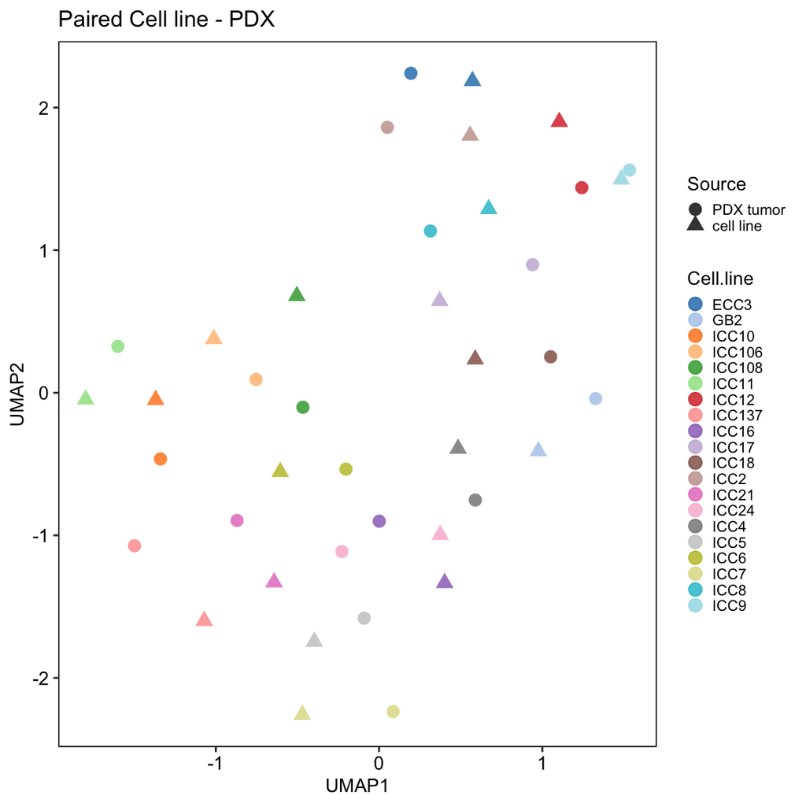

```r
d3_category20 <- c(
  "#1f77b4", "#aec7e8",
  "#ff7f0e", "#ffbb78",
  "#2ca02c", "#98df8a",
  "#d62728", "#ff9896",
  "#9467bd", "#c5b0d5",
  "#8c564b", "#c49c94",
  "#e377c2", "#f7b6d2",
  "#7f7f7f", "#c7c7c7",
  "#bcbd22", "#dbdb8d",
  "#17becf", "#9edae5"
)


ggplot(umap_plot_df, aes(x = X1, y = X2)) +
  geom_point(size = 3, alpha = 0.8, aes(color = Cell.line, shape = Source)) +
  ggtitle("Paired Cell line - PDX") +
  scale_color_manual(values = d3_category20) +
  #geom_text_repel(aes(label=key), size = 3) +   # This puts sample names in, delete to get rid of those
  #scale_colour_manual(values = c(`cell line`= "#1B9E77", `PDX tumor`= "#E6AB02")) +
  xlab("UMAP1") +
  ylab("UMAP2") +
  theme_bw() +
  theme(text = element_text(size = 10),
        panel.grid.major = element_blank(),
        panel.grid.minor = element_blank(),
        plot.title = element_text(hjust = 0),
        legend.position = 'right',
        legend.text.align = 0,
        legend.key.size = unit(0.3, 'cm'),
        legend.spacing = unit(0.3, 'cm'),
        panel.background = element_rect(colour = "black", fill = "white"),
        axis.text.y=element_text(color="black", size=10),
        axis.text.x=element_text(color="black", size=10))
```

```r
ggsave(paste0(output_directory, 'RNAseq_UMAP_PDX-cell.pdf'), units = 'in', width = 6, height = 3.7)
```

## CHOL cell lines vs TCGA CHOL patients

Also include cell lines and patients of the other GI cancers to make contrasts. TCGA data was downloaded from [FIREHOSE Broad GDAC](https://gdac.broadinstitute.org/). Specifically, we use CHOL cholangiocarcinoma cohort, COADREAD Colorectal adenocarcinoma cohort, PAAD Pancreatic adenocarcinoma, STAD Stomach adenocarcinoma, ESCA Esophageal carcinoma, and Liver hepatocellular carcinoma. Download from `mRNA-seq Preprocess package` and use `_RSEM_all` file. This analysis was done using `RSEM` read file.

### clean up CHOL RSEM

!!! NOTE !!!: Sample numbers don’t add up. We have read counts for 49 CHOL cell lines while there are 56 cell lines with RNA data. The 7 missing samples are: ACH-001537 (KKU055), 4 cell lines from ACH-001834 (ICC10) series, ACH-001847 (ICC7), ACH-001855 (OZ). After an investigation, I found out that ICC10 was included in the newest DepMap database (22Q2). The rest 3 are still missing. Did these 3 samples fail to pass some QC steps so that they are not present in any of the DepMap portal version?

```r
icc_key <- key %>% filter(RNA == "1" & Subtype != 'HCC')

## Load RNAseq for CHOL cell lines
btc_rna_reads_file = 'Main_Data/RNA/rna_cell_lines_expected_counts.csv'
data_transcript_cl <- read.csv(paste0(input_directory, btc_rna_reads_file), row.names = 1)
data_transcript_cl <- data_transcript_cl[, which(colnames(data_transcript_cl) %in% icc_key$Cell_line)]
data_transcript_cl <- data_transcript_cl[, order(match(names(data_transcript_cl), icc_key$Cell_line))]#49
rownames(data_transcript_cl) <- sub(" .*", "", rownames(data_transcript_cl))

## Load RNAseq for other GI cancer cell lines
depmap_sample_info_file = 'Additional_Data/DepMap/RNA_20Q2/sample_info.csv'
other.key <- read.csv(paste0(input_directory, depmap_sample_info_file))#'ACH-000052'
other.key <- other.key %>% filter(!(DepMap_ID %in% icc_key$DepMap_ID))
key.liver <- other.key$DepMap_ID[other.key$lineage == "liver"]
key.pancreas <- other.key$DepMap_ID[other.key$lineage == "pancreas"]
key.colon <- other.key$DepMap_ID[other.key$lineage == "colorectal"]
key.gastric <- other.key$DepMap_ID[other.key$lineage == "gastric"]
key.esophagus <- other.key$DepMap_ID[other.key$lineage == "esophagus"]


depmap_rna_reads_file = 'Additional_Data/DepMap/RNA_20Q2/CCLE_RNAseq_reads.csv'
data_transcript <- read.csv(paste0(input_directory, depmap_rna_reads_file), row.names = 1)
colnames(data_transcript) <- sub("\\.\\..*$", "", colnames(data_transcript))
data_transcript <- data_transcript[!(rownames(data_transcript) %in% icc_key$DepMap_ID), ]
data_transcript_liver <- data_transcript[ which(rownames(data_transcript) %in% key.liver),] #24
data_transcript_pancreas <- data_transcript[ which(rownames(data_transcript) %in% key.pancreas),] #51
data_transcript_colon <- data_transcript[ which(rownames(data_transcript) %in% key.colon),] #67
data_transcript_gastric <- data_transcript[ which(rownames(data_transcript) %in% key.gastric),] #42
data_transcript_esophagus <- data_transcript[ which(rownames(data_transcript) %in% key.esophagus),] #32

data_transcript_GI <- rbind(data_transcript_liver, data_transcript_pancreas, data_transcript_colon, data_transcript_gastric, data_transcript_esophagus)


data_transcript_GI_t <- t(data_transcript_GI) #58,676

gene.key <- intersect(rownames(data_transcript_GI_t), rownames(data_transcript_cl))

data_transcript_cl_filtered = data_transcript_cl[which(rownames(data_transcript_cl)%in% gene.key) , ]
data_transcript_GI_filtered = data_transcript_GI_t[which(rownames(data_transcript_GI_t)%in% gene.key) , ]

gene.key=sort(gene.key)
data_transcript_cl_filtered = data_transcript_cl_filtered[gene.key, ]
data_transcript_GI_filtered = data_transcript_GI_filtered[gene.key, ]
```

### Integrate CHOL RSEM and other GI cancer RSEM

```r
work_dir = paste0(input_directory, 'Patients_Data/TCGA-RSEM_GI/')
## TCGA RSEM
tcga_chol <- fread(file = paste0(work_dir, "CHOL_RNAseq/CHOL.uncv2.mRNAseq_RSEM_all.txt"), header = T) %>%
  separate(col = `HYBRIDIZATION R` , into = c("geneName", 'ID'), sep = "\\|", remove = TRUE) %>%
  distinct(geneName, .keep_all = TRUE) %>%
  select(-ID) %>%
  column_to_rownames(., "geneName") %>%
  slice(-1)

tcga_liver <- fread(file =  paste0(work_dir, "LIHC_RNAseq/LIHC.uncv2.mRNAseq_RSEM_all.txt"), header = T) %>%
  separate(col = `HYBRIDIZATION R` , into = c("geneName", 'ID'), sep = "\\|", remove = TRUE) %>%
  distinct(geneName, .keep_all = TRUE) %>%
  select(-ID) %>%
  column_to_rownames(., "geneName") %>%
  slice(-1)

tcga_pan <- fread(file =  paste0(work_dir, "PAAD_RNAseq/PAAD.uncv2.mRNAseq_RSEM_all.txt"), header = T) %>%
  separate(col = `HYBRIDIZATION R` , into = c("geneName", 'ID'), sep = "\\|", remove = TRUE) %>%
  distinct(geneName, .keep_all = TRUE) %>%
  select(-ID) %>%
  column_to_rownames(., "geneName") %>%
  slice(-1)

tcga_gas <- fread(file =  paste0(work_dir, "STAD_RNAseq/STAD.uncv2.mRNAseq_RSEM_all.txt"), header = T) %>%
  separate(col = `HYBRIDIZATION R` , into = c("geneName", 'ID'), sep = "\\|", remove = TRUE) %>%
  distinct(geneName, .keep_all = TRUE) %>%
  select(-ID) %>%
  column_to_rownames(., "geneName") %>%
  slice(-1)

tcga_eso <- fread(file =  paste0(work_dir, "ESGA_RNAseq/ESCA.uncv2.mRNAseq_RSEM_all.txt"), header = T) %>%
  separate(col = `HYBRIDIZATION R` , into = c("geneName", 'ID'), sep = "\\|", remove = TRUE) %>%
  distinct(geneName, .keep_all = TRUE) %>%
  select(-ID) %>%
  column_to_rownames(., "geneName") %>%
  slice(-1)

tcga_colo <- fread(file =  paste0(work_dir, "CRC_RNAseq/COADREAD.uncv2.mRNAseq_RSEM_all.txt"), header = T) %>%
  separate(col = `HYBRIDIZATION R` , into = c("geneName", 'ID'), sep = "\\|", remove = TRUE) %>%
  distinct(geneName, .keep_all = TRUE) %>%
  select(-ID) %>%
  column_to_rownames(., "geneName") %>%
  slice(-1)

common_rows <- Reduce(intersect, list(rownames(tcga_chol), rownames(tcga_liver), rownames(tcga_pan), rownames(tcga_gas),
                                      rownames(tcga_eso), rownames(tcga_colo)))

tcga_chol <- tcga_chol[common_rows, ]
tcga_liver <- tcga_liver[common_rows, ]
tcga_pan <- tcga_pan[common_rows, ]
tcga_gas <- tcga_gas[common_rows, ]
tcga_eso <- tcga_eso[common_rows, ]
tcga_colo <- tcga_colo[common_rows, ]



data_tcga <- cbind(tcga_chol, tcga_liver, tcga_pan, tcga_gas, tcga_eso, tcga_colo)
```

```r
## combine cell line and patient matrix
gene.key.final <- intersect(rownames(data_tcga), rownames(data_transcript_cl_filtered)) #15,709

# data_transcript_cl_filtered <- data_transcript_cl
# data_transcript_GI_filtered <- data_transcript_GI_t
data_transcript_tcga <- data_tcga

data_transcript_tcga <- data_transcript_tcga[which( rownames(data_transcript_tcga)%in% gene.key.final) , ]

data_transcript_merged <- merge(data_transcript_cl_filtered, data_transcript_GI_filtered, by.x = 0, by.y = 0, all.x = T, all.y = F)
data_transcript_merged <- data_transcript_merged[which(data_transcript_merged$Row.names %in% gene.key.final) , ]
data_transcript_merged_2 <- merge(data_transcript_merged, data_transcript_tcga, by.x = "Row.names", by.y = 0, all.x = F, all.y = T) %>% column_to_rownames(., "Row.names")
```

### UMAP calculation

```r
## colData
colData.cl <- data.frame(sample = c(
                                    colnames(data_transcript_cl_filtered),
                                    rownames(data_transcript_liver),
                                    rownames(data_transcript_pancreas),
                                    rownames(data_transcript_colon),
                                    rownames(data_transcript_gastric),
                                    rownames(data_transcript_esophagus)
                                    ),
                      source = "cell line",
                      lineage = c(
                        rep("bile duct", length(colnames(data_transcript_cl_filtered))),
                        rep("liver", length(rownames(data_transcript_liver))),
                        rep("pancreas", length(rownames(data_transcript_pancreas))),
                        rep("colon", length(rownames(data_transcript_colon))),
                        rep("gastric", length(rownames(data_transcript_gastric))),
                        rep("esophagus", length(rownames(data_transcript_esophagus)))
                                ))


colData.tcga <- data.frame(sample = c(colnames(tcga_chol),
                                      colnames(tcga_liver),
                                      colnames(tcga_pan),
                                      colnames(tcga_gas),
                                      colnames(tcga_eso),
                                      colnames(tcga_colo)),
                           source = "patient tumor",
                           lineage = c(
                             rep("bile duct", length(colnames(tcga_chol))),
                             rep("liver", length(colnames(tcga_liver))),
                             rep("pancreas", length(colnames(tcga_pan))),
                             rep("gastric", length(colnames(tcga_gas))),
                             rep("esophagus", length(colnames(tcga_eso))),
                             rep("colon", length(colnames(tcga_colo)))
                           ))

colData.3 <- rbind(colData.cl, colData.tcga)
```

```r
set.seed(seed)
# A-2. Verify that sample names and colnames are the same
# make sure sample names are in the same order in sample and count table files
all(colData.3$sample %in% colnames(data_transcript_merged_2))
```

```
[1] TRUE
```

```r
all(colData.3$sample == colnames(data_transcript_merged_2))
```

```
[1] TRUE
```

```r
cts <- as.data.frame.matrix( data_transcript_merged_2[, colData.3$sample] )
all(colData.3$sample == colnames(cts))
```

```
[1] TRUE
```

```r
## A-3. Create a DEseqDataSet from txi count table
cts <- round(cts)

dds <- DESeqDataSetFromMatrix(countData = cts,
                              colData = colData.3,
                              design = ~ 1)
## A-4. Perform a vst transformation on count data
rld <- vst(dds, blind=TRUE)

## use limma tool to remove batch effect for clutsering/PCA analysis
## here we use this function to remove effects from source (PDX and cell line)
bc <- assay(rld)
bc <- limma::removeBatchEffect(bc, batch = rld$source)
assay(rld) <- bc

## Normalized count table
normalized_counts <- assay(rld) %>% t() # We need to transpose this data so each row is a sample
```

### UMAP visual

```r
## run UMAP
# Set RNG kind explicitly to ensure reproducibility across systems
RNGkind("Mersenne-Twister", "Inversion", "Rejection")
set.seed(seed)

umap_results <- umap::umap(normalized_counts)

umap_plot_df <- data.frame(umap_results$layout) %>%
  tibble::rownames_to_column("sample") %>%
  dplyr::inner_join(colData.3, by = "sample")

names(umap_plot_df) = c("sample", "UMAP1", "UMAP2", "source", "lineage")

umap_plot_df$lineage <- factor(umap_plot_df$lineage, level = c("esophagus", "gastric", "liver", "colon", "pancreas", "bile duct"))

write.csv(umap_plot_df, paste0(output_directory, 'UMAP_TCGA_DepMap_GI_flat.csv'), row.names = F)

umap_plot_df
```

| sample | UMAP1 | UMAP2 | source | lineage |
| --- | --- | --- | --- | --- |
| SNU869 | -0.951282440 | -0.946655173 | cell line | bile duct |
| SNU478 | 0.853562696 | 2.234013589 | cell line | bile duct |
| TGBC52TKB | -0.095758540 | -0.050338695 | cell line | bile duct |
| AOVC1 | -0.750307767 | -0.868432596 | cell line | bile duct |
| SNU245 | 2.282607460 | 4.236953546 | cell line | bile duct |
| SNU1196 | 1.293817956 | 1.839812872 | cell line | bile duct |
| EGI1 | -1.018294537 | -1.066611938 | cell line | bile duct |
| KKU100 | 0.106941808 | -0.016211894 | cell line | bile duct |
| TFK1 | 0.651835011 | 2.184528124 | cell line | bile duct |
| ECC3 | -1.035985612 | -0.411345316 | cell line | bile duct |

[output cut: 2229 more lines]

```r
## read UMAP flat file
umap_plot_df <- read.csv(paste0(output_directory, 'UMAP_TCGA_DepMap_GI_flat.csv'), row.names = 1)
umap_plot_df$lineage <- factor(umap_plot_df$lineage, level = c("esophagus", "gastric", "liver", "colon", "pancreas", "bile duct"))
head(umap_plot_df)
```

|  | UMAP1 | UMAP2 | source | lineage |
| --- | --- | --- | --- | --- |
| SNU869 | -0.95128244 | -0.9466552 | cell line | bile duct |
| SNU478 | 0.85356270 | 2.2340136 | cell line | bile duct |
| TGBC52TKB | -0.09575854 | -0.0503387 | cell line | bile duct |
| AOVC1 | -0.75030777 | -0.8684326 | cell line | bile duct |
| SNU245 | 2.28260746 | 4.2369535 | cell line | bile duct |
| SNU1196 | 1.29381796 | 1.8398129 | cell line | bile duct |

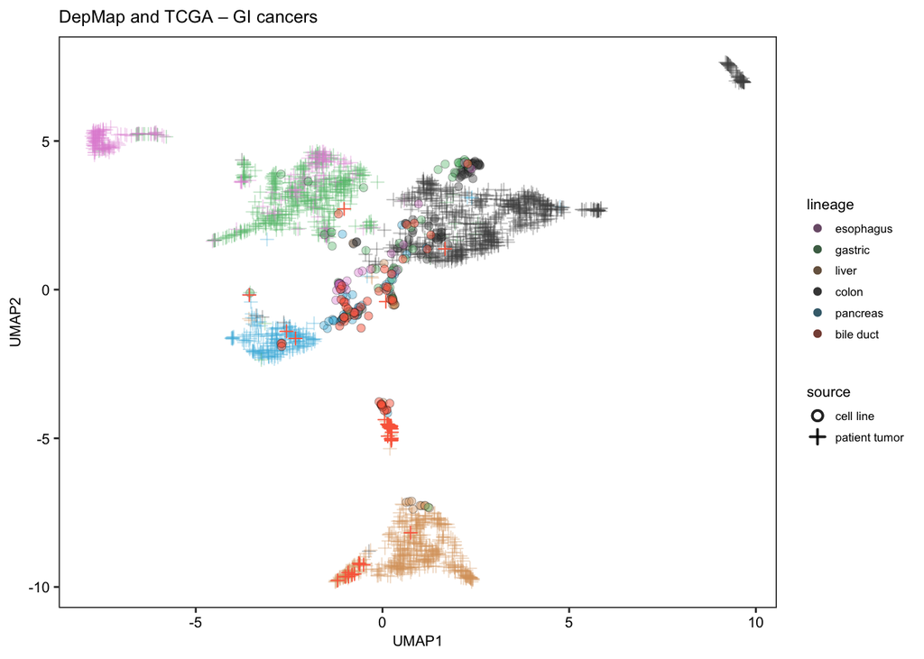

```r
## create layers for data visual
umap_plot_df_cl <- umap_plot_df %>% filter(source == "cell line" & lineage != "bile duct")
umap_plot_df_cl_chol <- umap_plot_df %>% filter(source == "cell line" & lineage == "bile duct")
umap_plot_df_pat <- umap_plot_df %>% filter(source == "patient tumor" & lineage != "bile duct")
umap_plot_df_chol <- umap_plot_df %>% filter(lineage == "bile duct" & source == "patient tumor")


color <- hcl.colors(8, palette = "Set2")
point_size = 2
cross_size = 2
border_color = 'black'
stroke_thickness = .2
## UMAP plotting
ggplot(umap_plot_df, aes(x = UMAP1, y = UMAP2, shape = source)) +
  ggtitle('DepMap and TCGA – GI cancers')+
    geom_point(data = umap_plot_df_pat, size = cross_size, aes(shape = source, color = lineage), alpha = 1/3) +
    geom_point(data = umap_plot_df_cl, size = point_size, aes(shape = source, fill = lineage), alpha = 0.4, stroke = stroke_thickness, color=border_color) +
  geom_point(data = umap_plot_df_chol, size = cross_size,  aes(shape = source, color = lineage), alpha = 1) +
  geom_point(data = umap_plot_df_cl_chol, size = point_size,  aes(shape = source, fill = lineage), alpha = 0.5, stroke = stroke_thickness, color=border_color) +
  scale_colour_manual(values = c("bile duct" = "#fb6a4a", "esophagus" = color[8],
                              "gastric" = color[4], "liver" = color[2], "colon" = "grey30", "pancreas" = color[6])) +
  scale_fill_manual(values = c("bile duct" = "#fb6a4a", "esophagus" = color[8],
                              "gastric" = color[4], "liver" = color[2], "colon" = "grey30", "pancreas" = color[6])) +
  scale_shape_manual(values = c("cell line" = 21, "patient tumor" = 3)) +
  theme_bw() +
  theme(text = element_text(size = 8),
        panel.grid.major = element_blank(),
        panel.grid.minor = element_blank(),
        plot.title = element_text(hjust = 0),
        legend.position = 'right',
        legend.text.align = 0,
        legend.key.size = unit(0.8, 'lines'),
        panel.background = element_rect(colour = "black", fill = "white"),
        axis.text.y=element_text(color="black", size=8),
        axis.text.x=element_text(color="black", size=8)) +
  guides(
      # fill = guide_legend(override.aes = list(size=3, alpha = .3, stroke = .3)),  # Fix legend fill and stroke
      color = guide_legend(override.aes = list(alpha = 0.4, stroke = .1)),  # Fix legend fill and stroke
    shape = guide_legend(override.aes = list(color = "black", alpha = 0.4, stroke = 1))  # Control border stroke
  )
```

```r
ggsave(paste0(output_directory,  'RNAseq_UMAP_allGI_cl_vs_patient.pdf'), units = 'in', width = 6, height = 3)
```

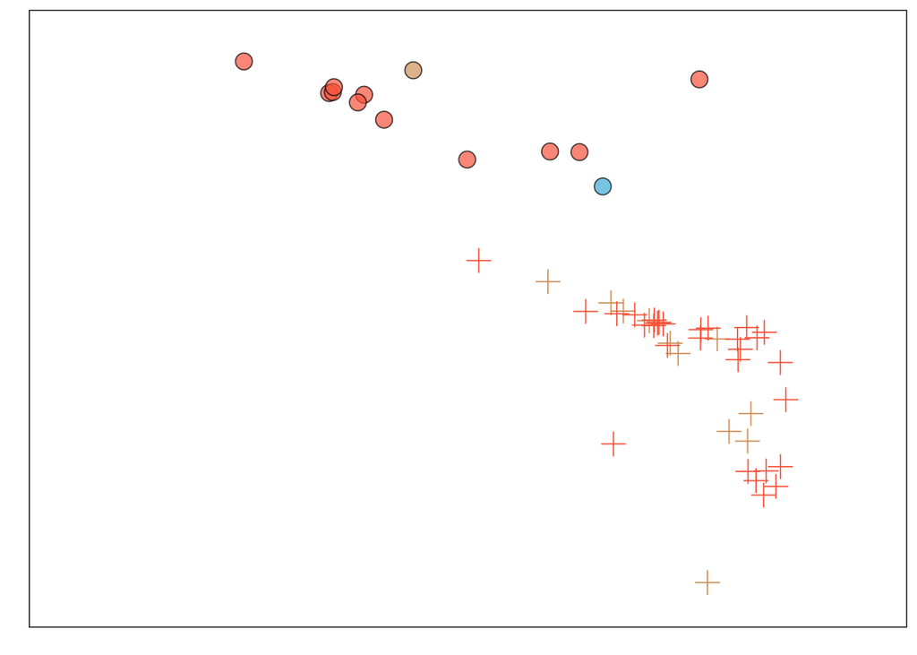

```r
## UMAP zoom-in
ggplot(umap_plot_df, aes(x = UMAP1, y = UMAP2, shape = source)) +
  # geom_point(data = umap_plot_df, size = 5.5, aes(shape = source), color = "black" ) +
#   geom_point(data = umap_plot_df, size = 7.3, aes(shape = source, color = lineage), alpha = 0.8) +
# geom_point(data = umap_plot_df_chol, size = 8, aes(shape = source, color = lineage)) +
      geom_point(data = umap_plot_df_pat, size = 4, aes(shape = source, color = lineage), alpha = 1) +
    geom_point(data = umap_plot_df_cl, size = 4, aes(shape = source, fill = lineage), alpha = .7) +
  geom_point(data = umap_plot_df_chol, size = 4,  aes(shape = source, color = lineage), alpha =1) +
        geom_point(data = umap_plot_df_cl_chol, size = 4,  aes(shape = source, fill = lineage), alpha = .7) +
   scale_colour_manual(values = c("bile duct" = "#fb6a4a", "esophagus" = color[8],
                              "gastric" = color[4], "liver" = color[2], "colon" = "grey30", "pancreas" = color[6])) +
        scale_fill_manual(values = c("bile duct" = "#fb6a4a", "esophagus" = color[8],
                              "gastric" = color[4], "liver" = color[2], "colon" = "grey30", "pancreas" = color[6])) +
  scale_shape_manual(values = c("cell line" = 21, "patient tumor" = 3)) +
          scale_x_continuous("", limits = c(-.2, .3)) +
  # scale_y_continuous("", limits = c(-5, -3.6)) +
  scale_y_continuous("", limits = c(-5.4, -3.7)) +
  # scale_x_continuous("", limits = c(-3, 2)) +
  # scale_y_continuous("", limits = c(-8, -5)) +
  # scale_x_continuous("", limits = c(-1.25, -0.9)) +
  # scale_y_continuous("", limits = c(-5, -.65)) +
  # scale_x_continuous("", limits = c(-0.5, 0.2)) +
  # scale_y_continuous("", limits = c(3, 5)) +
  theme_bw() +
  theme(text = element_text(size = 1, color = "white"),
        panel.grid.major = element_blank(),
        panel.grid.minor = element_blank(),
        plot.title = element_text(hjust = 0),
        legend.position = 'none',
        axis.ticks=element_blank(),
        legend.text.align = 0,
        legend.key.size = unit(1, 'lines'),
        panel.background = element_rect(colour = "black", fill = "white"),
        axis.text.y=element_text(color="white", size=1),
        axis.text.x=element_text(color="white", size=1))
```

```r
ggsave(paste0(output_directory,  'RNAseq_UMAP_allGI_cl_vs_patient_zoom2.pdf'), units = 'in', width =2, height = 2)
```